# priors

Mark Hagemann

November 2, 2016

The hydroSWOT dataset allows us to mine for the following prior distributions:

### Ao (conditional on W statistics) –

[[1]][1] “alm”

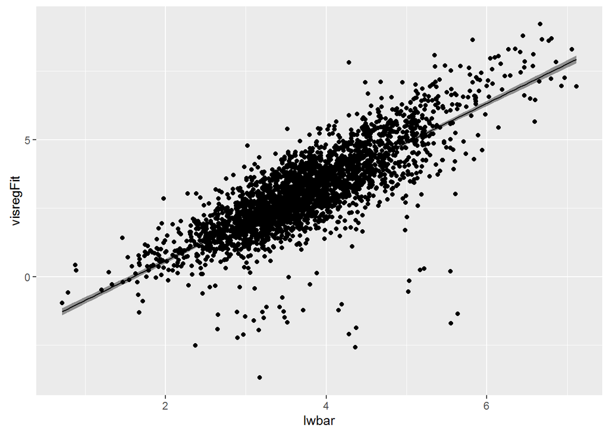

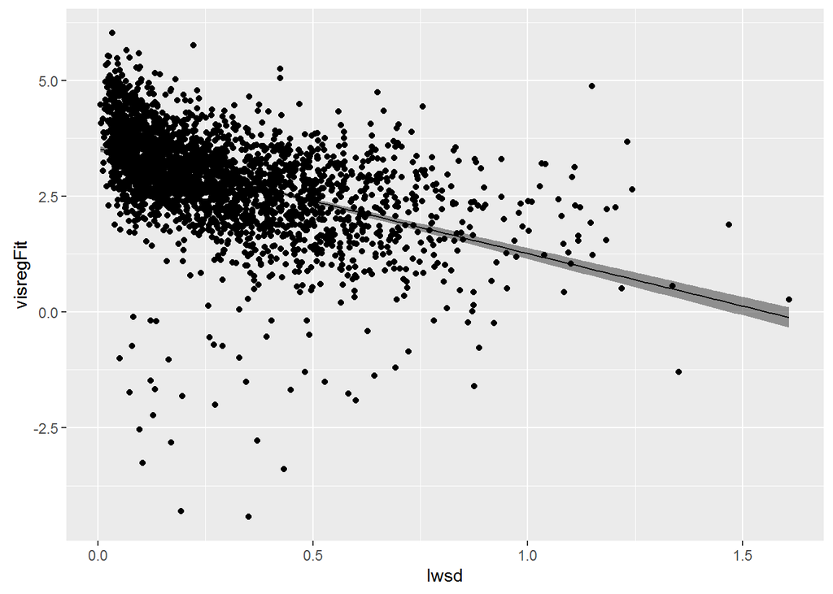

|  | *Dependent variable:* |
| --- | --- |
|  | lAo |
| lwbar | 1.438*** |
|  | (0.021) |
| lwsd | -2.268*** |
|  | (0.082) |
| Constant | -1.782*** |
|  | (0.087) |
| Observations | 2,704 |
| R<sup>2</sup> | 0.696 |
| Adjusted R<sup>2</sup> | 0.696 |
| Residual Std. Error | 0.948 (df = 2701) |
| F Statistic | 3,092.872*** (df = 2; 2701) |
| *Note:* | p<0.1; p<0.05; p<0.01 |

The standard deviation comes from the GCV:

```r
sqrt(gcv(alm))
```

[1] 0.9480744

### b (conditional on sd(logW))

- truncated normal with mean 0.0231 + 0.454 * sd(logW), variance 0.00975

[[1]][1] “blm”

[[1]][1] “bpreddat”

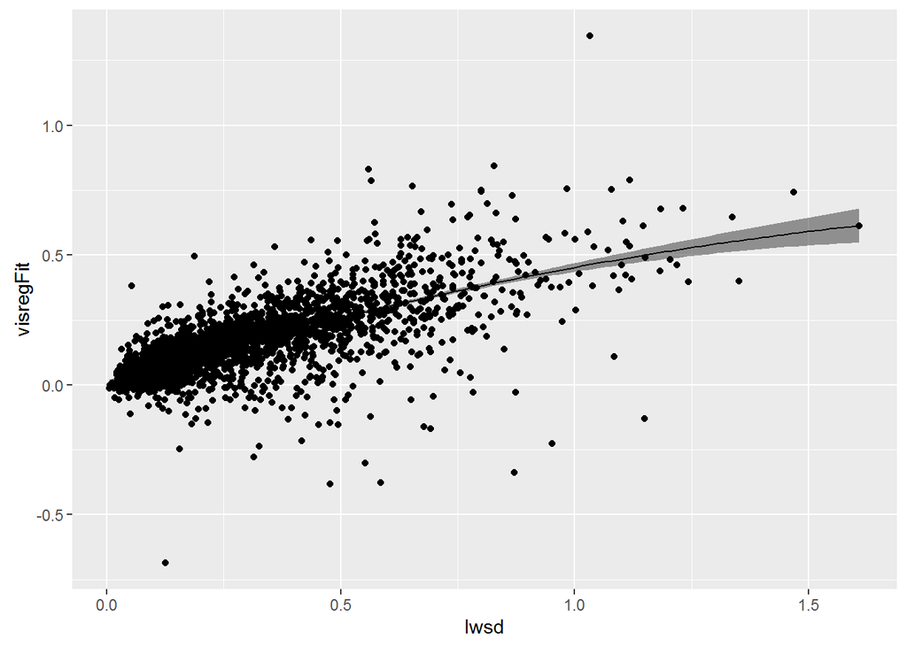

|  | *Dependent variable:* |
| --- | --- |
|  | bhat |
| poly(lwsd, degree = 2)1 | 5.303*** |
|  | (0.098) |
| poly(lwsd, degree = 2)2 | -0.448*** |
|  | (0.098) |
| Constant | 0.153*** |
|  | (0.002) |
| Observations | 2,679 |
| R<sup>2</sup> | 0.526 |
| Adjusted R<sup>2</sup> | 0.526 |
| Residual Std. Error | 0.098 (df = 2676) |
| F Statistic | 1,486.027*** (df = 2; 2676) |
| *Note:* | p<0.1; p<0.05; p<0.01 |

The standard deviation comes from the GCV:

```r
sqrt(gcv(blm))
```

[1] 0.09767724

### AHG error: (don’t actually need this–see math)

- relate to cor(logW, logQ)
- $var(e_{ahg}) = var(logW) - b^2var(logQ)$

### logQ

[[1]][1] “qsdlm”

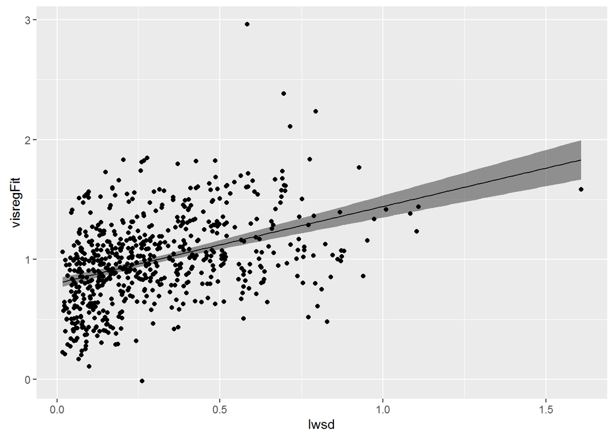

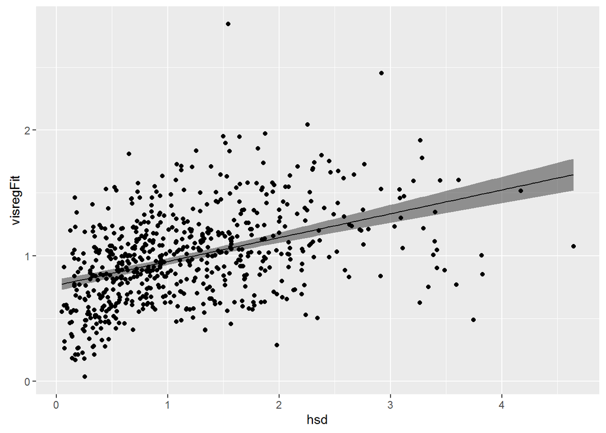

|  | *Dependent variable:* |
| --- | --- |
|  | lqsd |
| lwsd | 0.640*** |
|  | (0.062) |
| hsd | 0.190*** |
|  | (0.018) |
| Constant | 0.616*** |
|  | (0.026) |
| Observations | 642 |
| R<sup>2</sup> | 0.356 |
| Adjusted R<sup>2</sup> | 0.354 |
| Residual Std. Error | 0.333 (df = 639) |
| F Statistic | 176.600*** (df = 2; 639) |
| *Note:* | p<0.1; p<0.05; p<0.01 |

The standard deviation comes from the GCV:

```r
sqrt(gcv(qsdlm))
```

[1] 0.3339897

### logn

Prior is normal(-3.5, 1). Resulting in a lognormal(-3.5, 1) prior on n. That looks like:

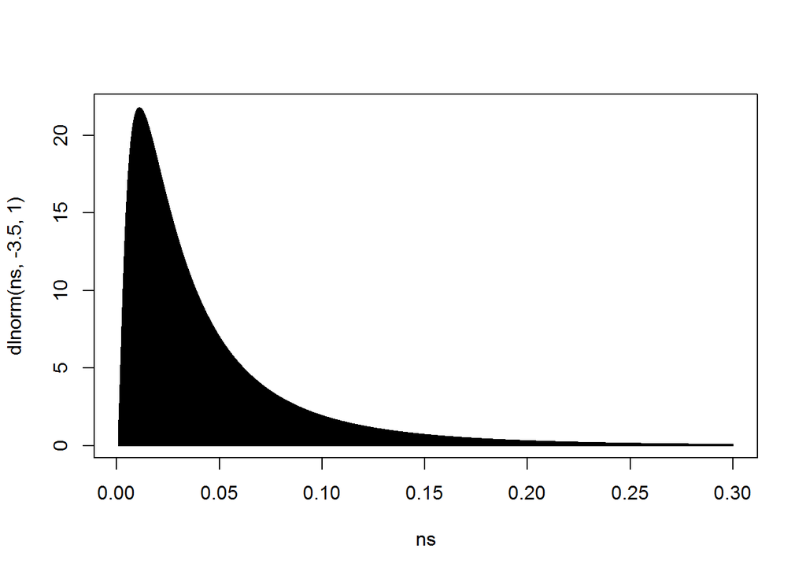

### Manning error

I haven’t found a good source for Manning’s error statistics. But Dingman (1997) gives RMSE of log10(Q) for a couple modifications of Manning’s equation. This is given as about 0.25.

### logQc

We still don’t really know what Qc represents, physically. So hard to constrain at this point. But best guess is it’s near mean(logQ)

### logWc

Also not sure on this one. We’ll know more when we get an AMHG validation set.